# Project Wine 820

Section I : Introduction

```
        This report is done to illustrate how wine quality can be predicted by using knn, rf and nn.  It will also show what other algos have been used in other reports. A comparison will be drawn along with some recommendations.
```

Section II : Related Works

[output not shown]

Section III : Methodologies

[output not shown]

Section IV : Results and Discussion

[output not shown]

Section V : Conclusion and Future Work

```r
###  Load white wine dataset
wine <- read.csv("winequality-white.csv", header = T , stringsAsFactors = F, sep = ";", na.strings = c("","NA"))
# had to use sep = ";" since csv is not comma separated

wine_data_nn <- read.csv("winequality-white.csv", header = T , stringsAsFactors = F, sep = ";", na.strings = c("","NA"))
head(wine)
```

```
##   fixed.acidity volatile.acidity citric.acid residual.sugar chlorides
## 1           7.0             0.27        0.36           20.7     0.045
## 2           6.3             0.30        0.34            1.6     0.049
## 3           8.1             0.28        0.40            6.9     0.050
## 4           7.2             0.23        0.32            8.5     0.058
## 5           7.2             0.23        0.32            8.5     0.058
## 6           8.1             0.28        0.40            6.9     0.050
##   free.sulfur.dioxide total.sulfur.dioxide density   pH sulphates alcohol
## 1                  45                  170  1.0010 3.00      0.45     8.8
## 2                  14                  132  0.9940 3.30      0.49     9.5
## 3                  30                   97  0.9951 3.26      0.44    10.1
## 4                  47                  186  0.9956 3.19      0.40     9.9
## 5                  47                  186  0.9956 3.19      0.40     9.9
## 6                  30                   97  0.9951 3.26      0.44    10.1
##   quality
## 1       6
## 2       6
## 3       6
## 4       6
## 5       6
## 6       6
```

```r
str(wine)
```

```
## 'data.frame':    4898 obs. of  12 variables:
##  $ fixed.acidity       : num  7 6.3 8.1 7.2 7.2 8.1 6.2 7 6.3 8.1 ...
##  $ volatile.acidity    : num  0.27 0.3 0.28 0.23 0.23 0.28 0.32 0.27 0.3 0.22 ...
##  $ citric.acid         : num  0.36 0.34 0.4 0.32 0.32 0.4 0.16 0.36 0.34 0.43 ...
##  $ residual.sugar      : num  20.7 1.6 6.9 8.5 8.5 6.9 7 20.7 1.6 1.5 ...
##  $ chlorides           : num  0.045 0.049 0.05 0.058 0.058 0.05 0.045 0.045 0.049 0.044 ...
##  $ free.sulfur.dioxide : num  45 14 30 47 47 30 30 45 14 28 ...
##  $ total.sulfur.dioxide: num  170 132 97 186 186 97 136 170 132 129 ...
##  $ density             : num  1.001 0.994 0.995 0.996 0.996 ...
##  $ pH                  : num  3 3.3 3.26 3.19 3.19 3.26 3.18 3 3.3 3.22 ...
##  $ sulphates           : num  0.45 0.49 0.44 0.4 0.4 0.44 0.47 0.45 0.49 0.45 ...
##  $ alcohol             : num  8.8 9.5 10.1 9.9 9.9 10.1 9.6 8.8 9.5 11 ...
##  $ quality             : int  6 6 6 6 6 6 6 6 6 6 ...
```

" A histogram is the appropriate graph for the initial exploration of a continuous variable. By means of a set of vertical bars, it shows how the numerical values of that variable are distributed. The histogram allows to calculate the probability of representation of any value value of the continuous variable under study, which is great importance if we want to make inferences and estimate population values from the results of our sample.

A histogram provides a visual representation of the distribution of a dataset: location, spread and skewness of data; it also helps to visualize whether the distribution is symmetric or skewed left or right. In addition, if it is unimodal, bimodal or multimodal. It can also show any outliers or gaps in the data. In brief, a histogram summarizes the distribution properties of a continuous numerical variable. (Towards Data Science) "

from: www.towardsdatascience.com/histograms-why-how-431a5cfbfcd5

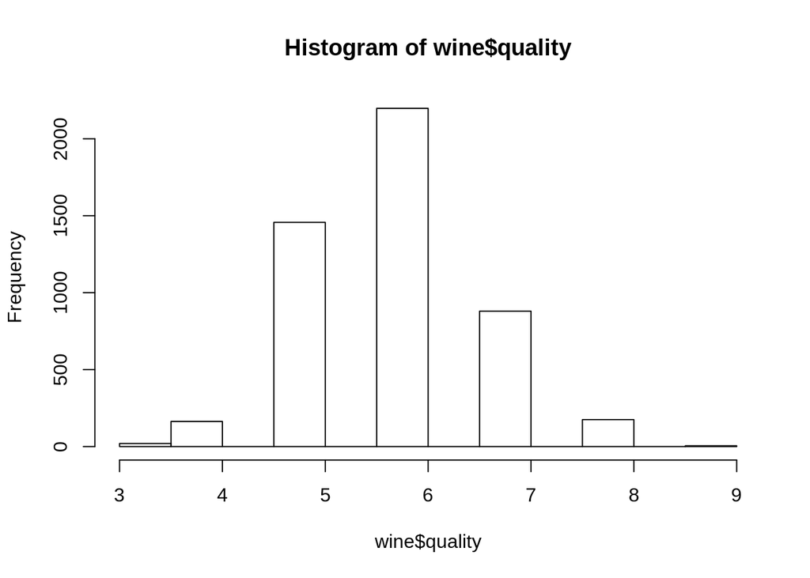

```r
hist(wine$quality)
```

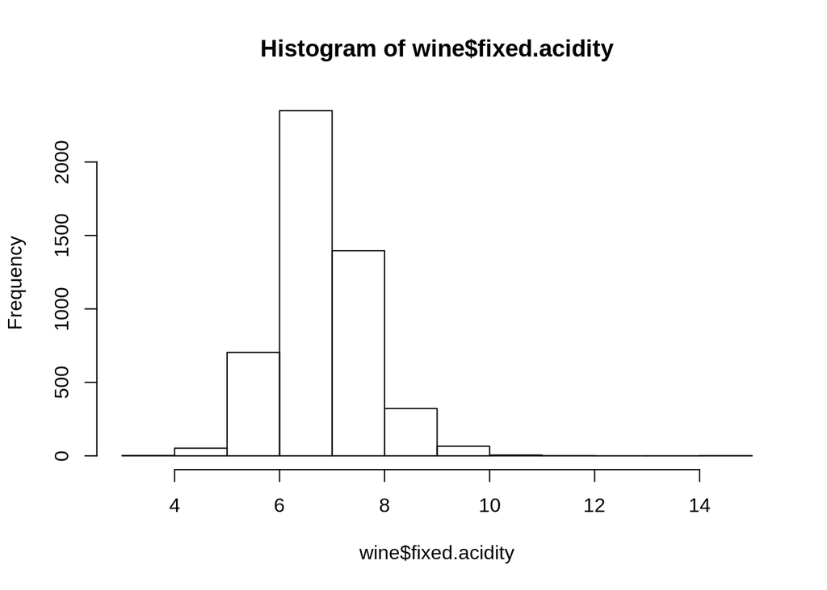

```r
hist(wine$fixed.acidity)
```

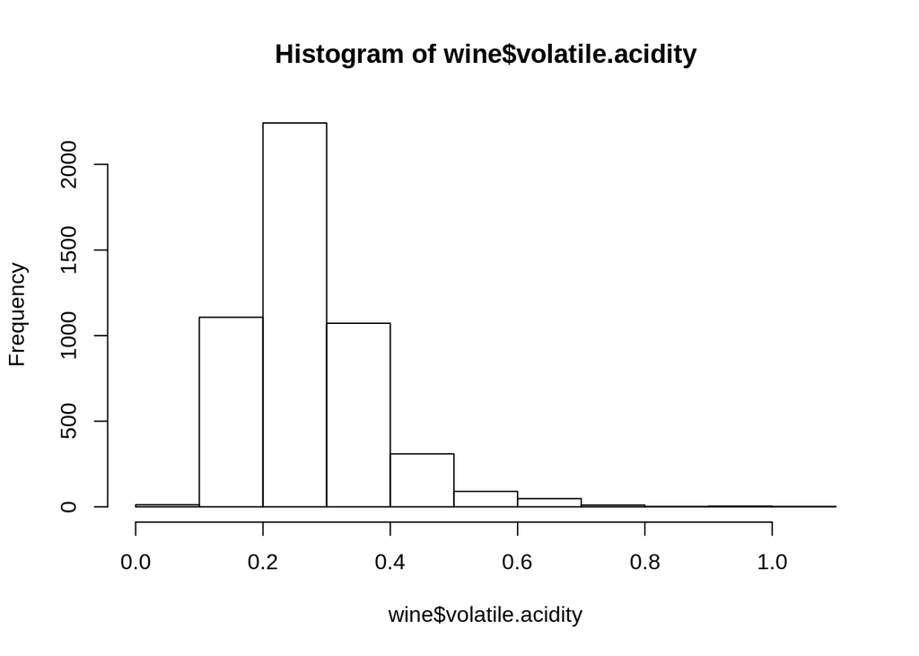

```r
hist(wine$volatile.acidity)
```

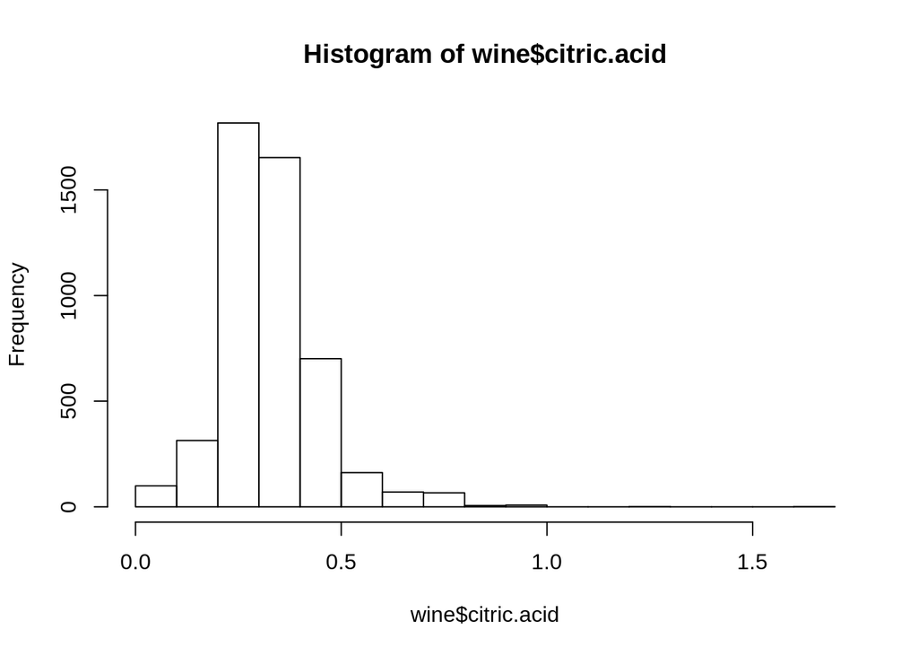

```r
hist(wine$citric.acid)
```

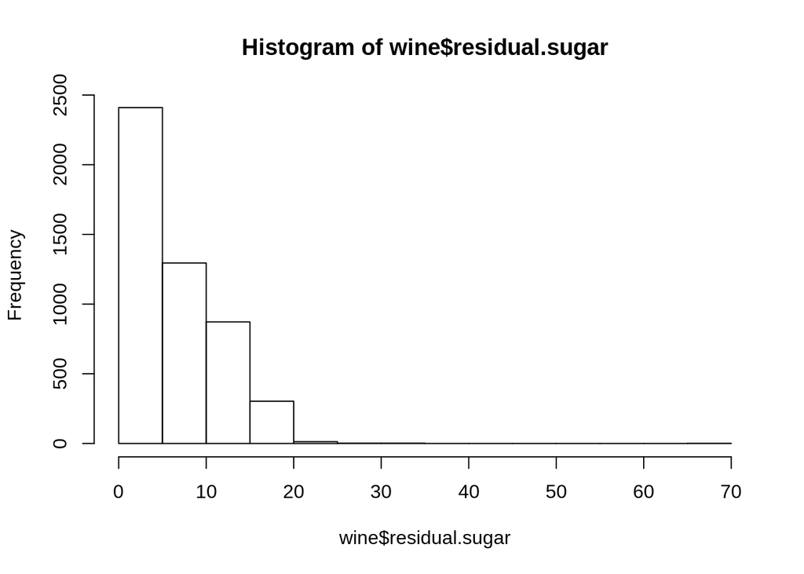

```r
hist(wine$residual.sugar)
```

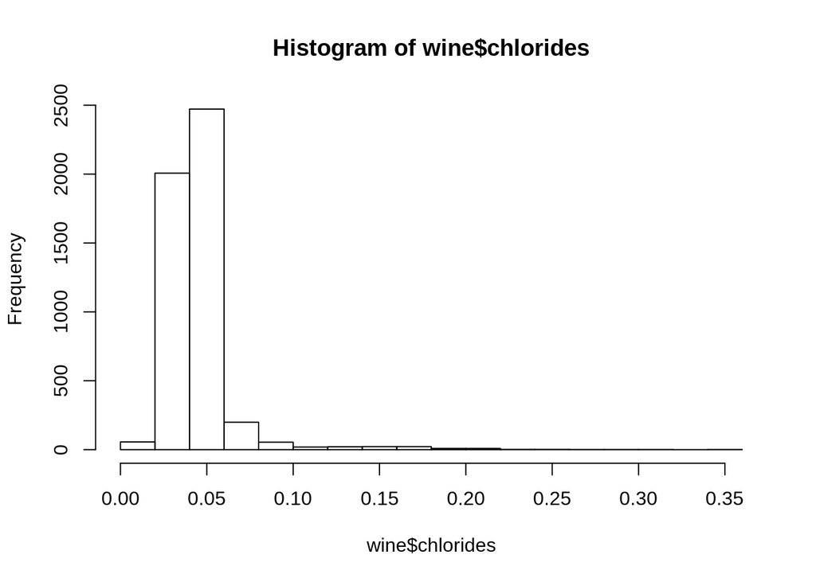

```r
hist(wine$chlorides)
```

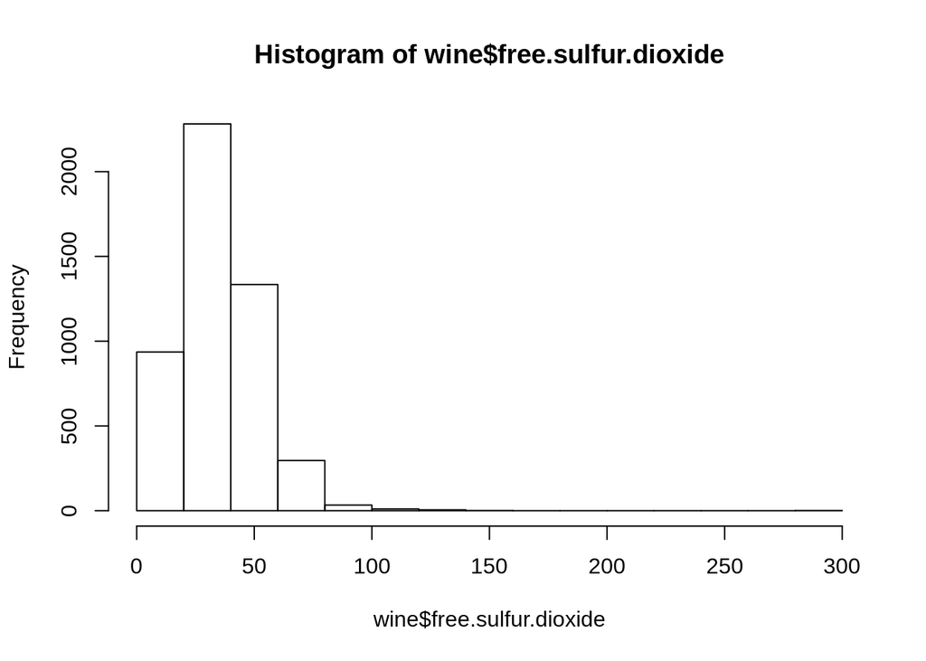

```r
hist(wine$free.sulfur.dioxide)
```

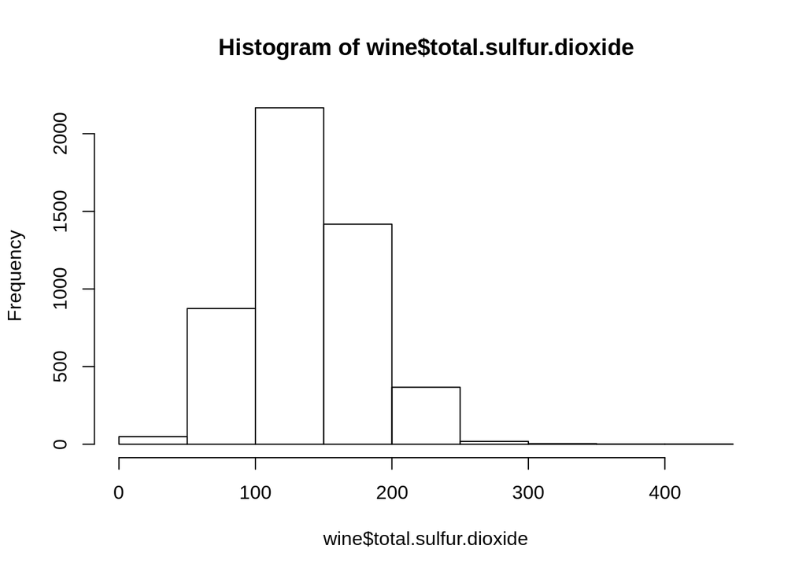

```r
hist(wine$total.sulfur.dioxide)
```

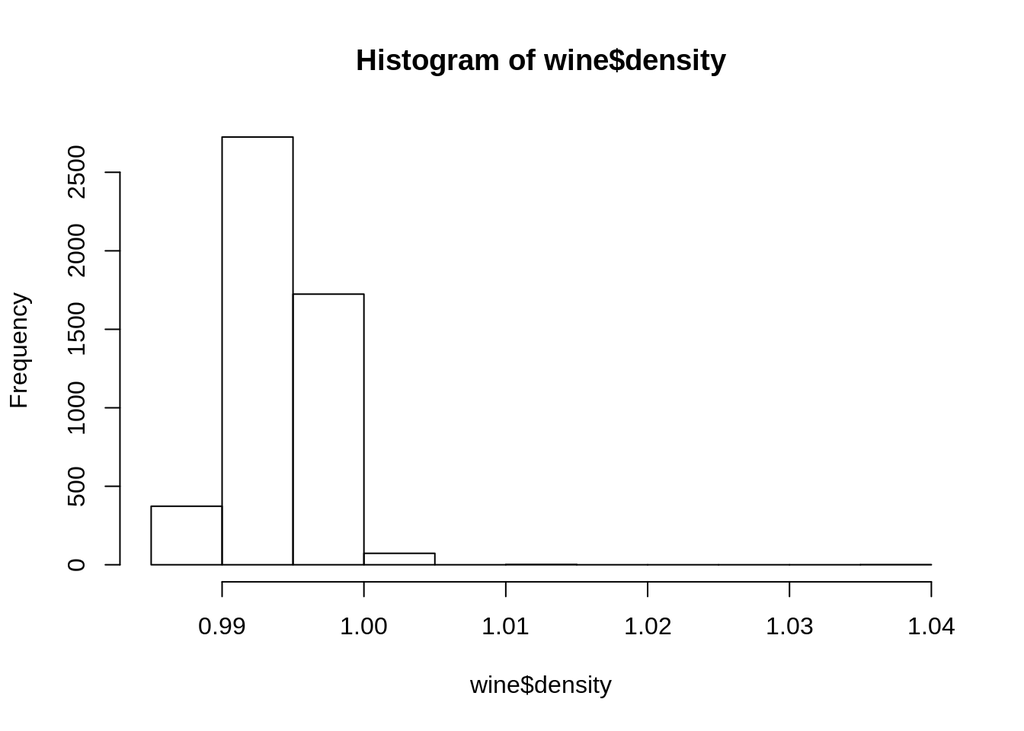

```r
hist(wine$density)
```

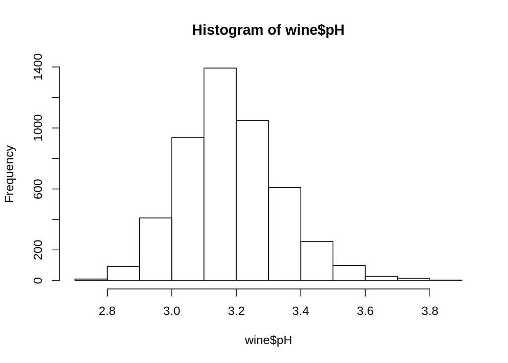

```r
hist(wine$pH)
```

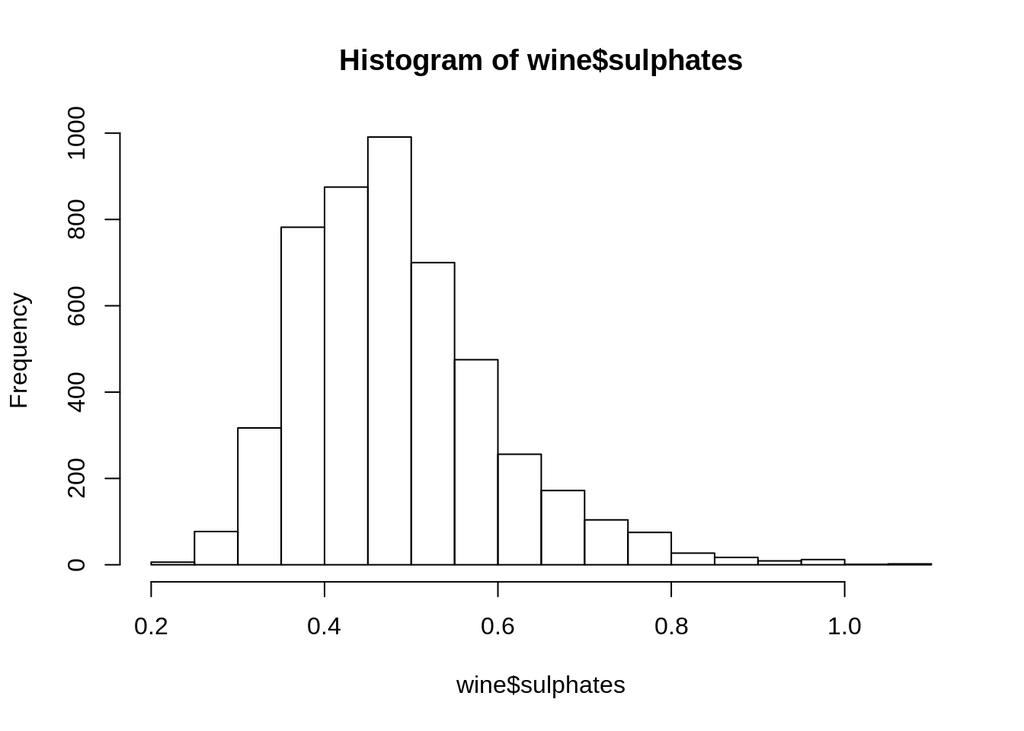

```r
hist(wine$sulphates)
```

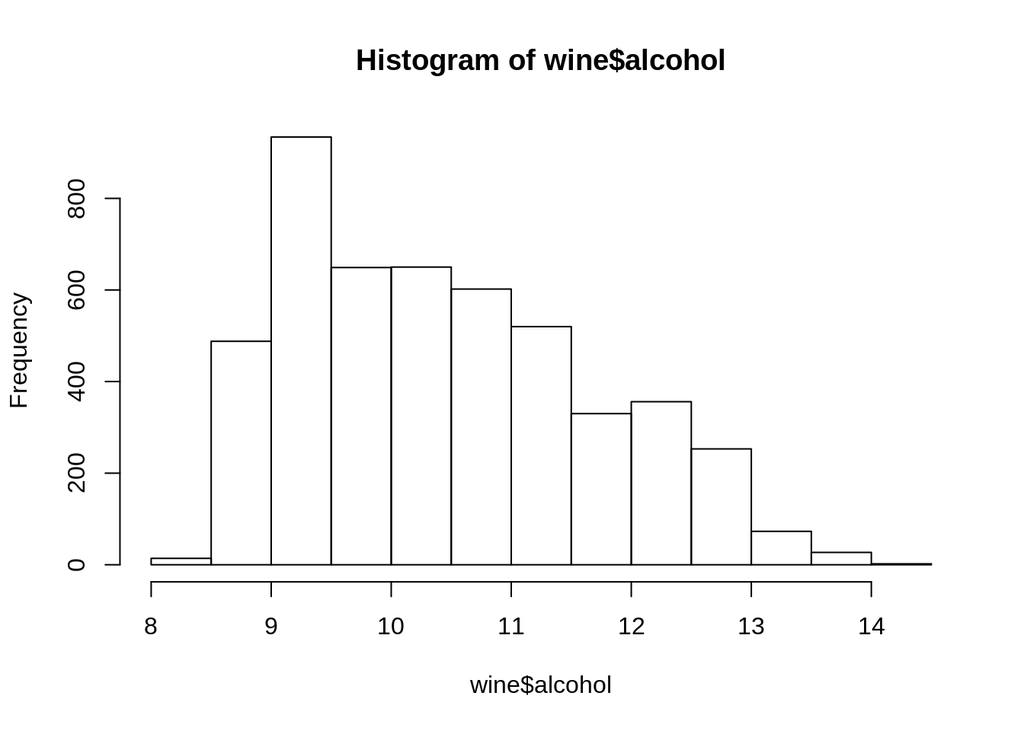

```r
hist(wine$alcohol)
```

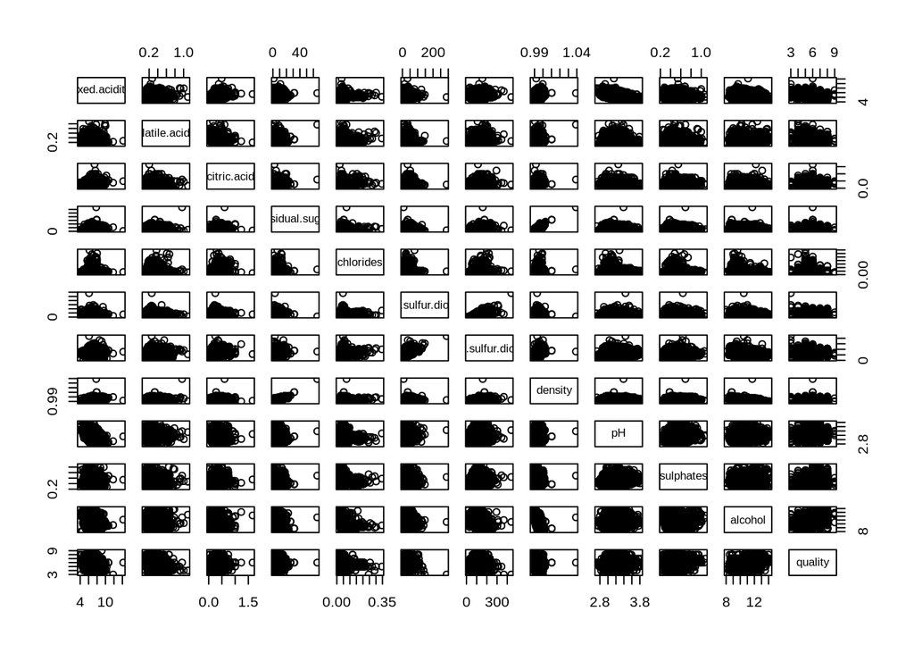

```r
plot(wine)
```

```r
### Selected features that most people would recognize

#subset_wine_PCA <- wine[,c("fixed.acidity","volatile.acidity ","citric.acid", "residual.sugar","chlorides","free.sulfur.dioxide", "total.sulfur.dioxide", "density", "pH", "sulphates", "alcohol")]

subset_wine_PCA <- wine[,c("fixed.acidity","volatile.acidity","citric.acid", "residual.sugar","chlorides","free.sulfur.dioxide","total.sulfur.dioxide", "density", "pH", "sulphates", "alcohol")]

subset_wine_W <- wine[,c("fixed.acidity","residual.sugar","density", "pH", "sulphates", "alcohol", "quality")]

print(head(subset_wine_W))
```

```
##   fixed.acidity residual.sugar density   pH sulphates alcohol quality
## 1           7.0           20.7  1.0010 3.00      0.45     8.8       6
## 2           6.3            1.6  0.9940 3.30      0.49     9.5       6
## 3           8.1            6.9  0.9951 3.26      0.44    10.1       6
## 4           7.2            8.5  0.9956 3.19      0.40     9.9       6
## 5           7.2            8.5  0.9956 3.19      0.40     9.9       6
## 6           8.1            6.9  0.9951 3.26      0.44    10.1       6
```

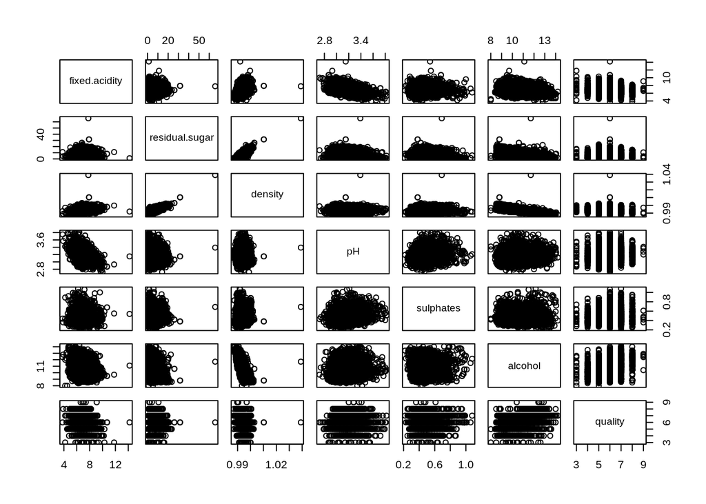

```r
plot(subset_wine_W)
```

Show correlation

```r
#install.packages("corrplot")
library(corrplot)
wine.cor <- cor(wine, method = "pearson")
```

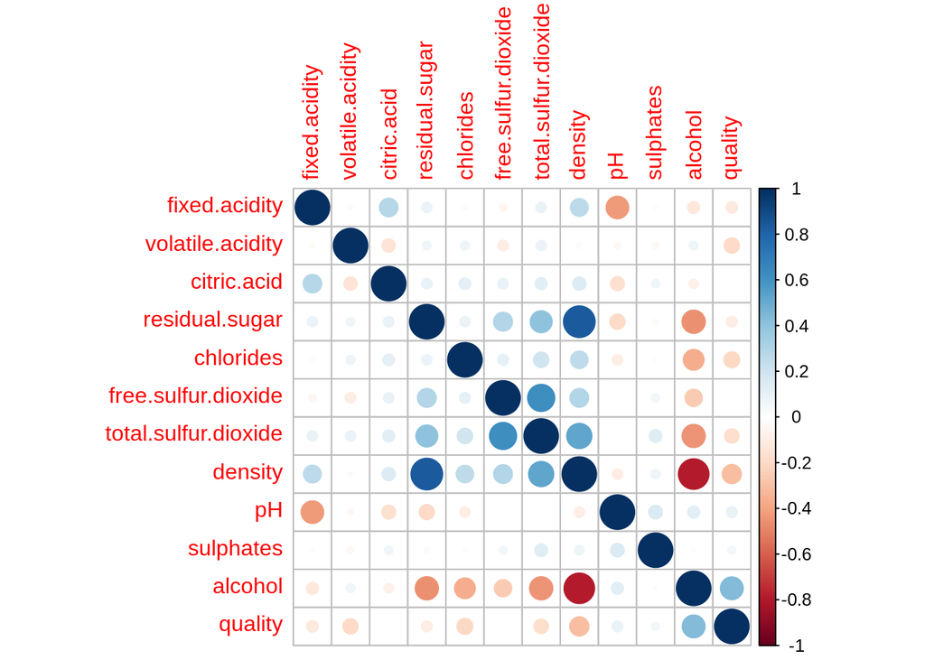

```r
corrplot(wine.cor)
```

### include comments in the report…

- We can see that alcohol is negatively correlated to density and that density is positively correlated to residual sugars.
- We also see that quality is positively correlated to alcohol.

```r
#subset_WW_ind <- subset_wine_W[,1:5]
#SS.WW.pca.rawdata <- prcomp(subset_WW_ind, scale = FALSE, center = FALSE)
#SS.WW.pca.rawdata


# PCA - Principal Component Analysis

# modify subset
wine_pca <- prcomp(subset_wine_W, scale. = FALSE, center = FALSE)
wine_pca
```

```
## Standard deviations (1, .., p=7):
## [1] 15.7622347  4.8088386  0.9841282  0.7143878  0.2971138  0.1110291  0.0311779
##
## Rotation (n x k) = (7 x 7):
##                        PC1         PC2         PC3          PC4         PC5
## fixed.acidity  -0.43251221  0.14567536  0.87126220 -0.105427649  0.14408420
## residual.sugar -0.43992139 -0.89434806 -0.06608630  0.044663939  0.01554573
## density        -0.06252990  0.02248462  0.02770229 -0.001450391 -0.19902040
## pH             -0.20025318  0.07980803  0.03483415 -0.004036419 -0.94008702
## sulphates      -0.03078199  0.01194816  0.01200950 -0.013292987 -0.15267132
## alcohol        -0.66080505  0.37990689 -0.35518736  0.517513095  0.15767174
## quality        -0.37118754  0.16605223 -0.32901618 -0.847865107  0.08635072
##                          PC6          PC7
## fixed.acidity  -0.0050167986  0.026714027
## residual.sugar  0.0009132872  0.002436876
## density        -0.0321263971 -0.976818155
## pH             -0.1532820269  0.212227831
## sulphates       0.9875620135  0.001231870
## alcohol         0.0104573245  0.007735513
## quality        -0.0076437162  0.002169479
```

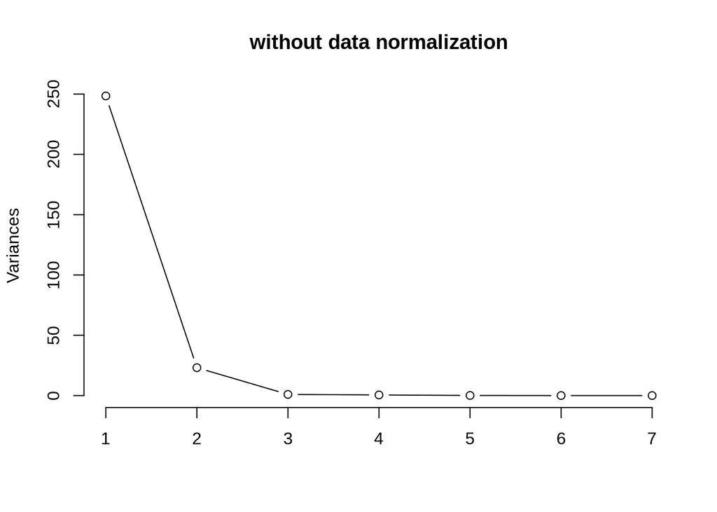

```r
#plot(SS.WW.pca.rawdata, type = "l", main = "without data normalization")

plot(wine_pca, type = "l", main = "without data normalization" )
```

```r
wine_pca_Full <- prcomp(wine, scale. = TRUE, center = TRUE)
wine_pca_Full
```

```
## Standard deviations (1, .., p=12):
##  [1] 1.8293903 1.2594008 1.1709706 1.0415668 0.9875644 0.9688978 0.8770680
##  [8] 0.8508195 0.7459900 0.5856051 0.5330248 0.1430703
##
## Rotation (n x k) = (12 x 12):
##                              PC1         PC2         PC3         PC4
## fixed.acidity        -0.15690447  0.56066866 -0.20738436  0.03373494
## volatile.acidity     -0.02428722  0.01606694  0.52491466 -0.13119747
## citric.acid          -0.13294430  0.28938115 -0.44635554  0.32953335
## residual.sugar       -0.40605288 -0.03882402 -0.03384313 -0.41615630
## chlorides            -0.21754400  0.03691144  0.21471269  0.50961203
## free.sulfur.dioxide  -0.27471931 -0.34554881 -0.31297088 -0.14892788
## total.sulfur.dioxide -0.39044148 -0.27232605 -0.12479447 -0.02161841
## density              -0.50129557 -0.01773344  0.03196758 -0.10386393
## pH                    0.13003701 -0.56714503  0.06848384  0.20410995
## sulphates            -0.03364168 -0.24826266 -0.22699505  0.51924489
## alcohol               0.44279498  0.01698188 -0.15887556 -0.13438871
## quality               0.22713722 -0.14603134 -0.48884718 -0.27820033
##                              PC5          PC6         PC7         PC8
## fixed.acidity        -0.24413933  0.105856235  0.22355921  0.13041311
## volatile.acidity     -0.70298193 -0.123704688 -0.22363601 -0.22960669
## citric.acid          -0.06510579 -0.131958661 -0.12037133 -0.69141866
## residual.sugar        0.01610213  0.289918546 -0.33860858 -0.11329401
## chlorides             0.17829248 -0.409317266 -0.55225504  0.21139734
## free.sulfur.dioxide  -0.11117214 -0.488085145  0.22407108  0.12883115
## total.sulfur.dioxide -0.27144774 -0.272493820  0.20375343  0.01290262
## density               0.07834373  0.326008106 -0.12313568 -0.08667076
## pH                    0.11270171  0.192688838  0.07704001 -0.47796137
## sulphates            -0.45623099  0.479811894 -0.04462167  0.33642752
## alcohol              -0.30855451 -0.135443327 -0.09801169 -0.08899029
## quality              -0.04112191 -0.005524396 -0.58434519  0.14444197
##                              PC9        PC10        PC11         PC12
## fixed.acidity        -0.63145048  0.20087123 -0.10411772  0.170792295
## volatile.acidity     -0.03159628 -0.14175876 -0.27002270  0.013376718
## citric.acid           0.24949503 -0.10632912 -0.05395597  0.009648802
## residual.sugar        0.17730336  0.37427490  0.17987291  0.493565139
## chlorides            -0.17916182  0.23552782  0.09108849  0.025168952
## free.sulfur.dioxide   0.10184710  0.32733415 -0.49921348 -0.029475198
## total.sulfur.dioxide -0.17800832 -0.34735757  0.64355326  0.035060193
## density              -0.12538636  0.04349161 -0.06686042 -0.761184485
## pH                   -0.52031593  0.18375599 -0.07911267  0.141842640
## sulphates             0.23662489  0.05519364 -0.04102077  0.042787387
## alcohol               0.01278298  0.57530003  0.41895440 -0.350156811
## quality              -0.29970621 -0.36771605 -0.14620225 -0.016069252
```

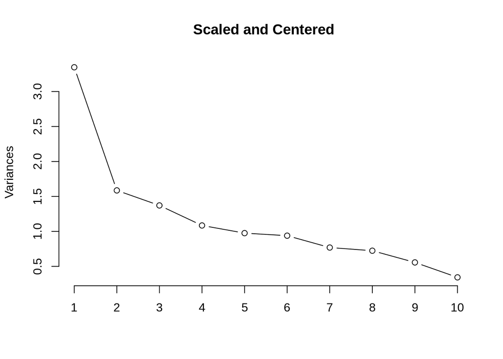

```r
plot(wine_pca_Full, type = "l", main = "Scaled and Centered " )
```

This is could work since Pearson correlation plot indicate that the four of first 6 features have at least some correlation with quality.

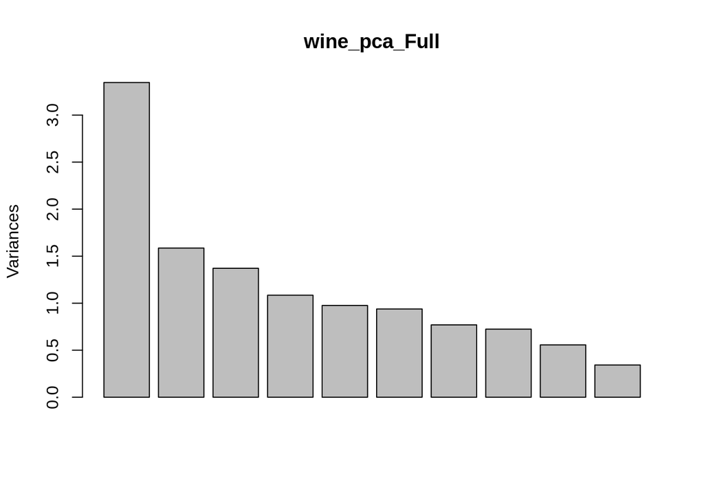

```r
plot(wine_pca_Full)
```

```r
wine_pca_for_Q <- prcomp(subset_wine_PCA, scale. = TRUE, center = TRUE)
wine_pca_for_Q
```

```
## Standard deviations (1, .., p=11):
##  [1] 1.7950638 1.2550856 1.1052924 1.0092187 0.9865772 0.9688867 0.8524072
##  [8] 0.7741825 0.6435399 0.5380401 0.1436979
##
## Rotation (n x k) = (11 x 11):
##                               PC1          PC2        PC3         PC4
## fixed.acidity         0.157218451 -0.587558208 -0.1213683 -0.01858383
## volatile.acidity      0.005089494  0.051728054  0.5909715 -0.27411517
## citric.acid           0.144049843 -0.345294562 -0.5043969 -0.14851432
## residual.sugar        0.427408368  0.008749392  0.2143199  0.27376531
## chlorides             0.212011065 -0.008800308  0.1023674 -0.71071228
## free.sulfur.dioxide   0.300334387  0.290355136 -0.2794101  0.30558549
## total.sulfur.dioxide  0.406652203  0.244032391 -0.1243753  0.06045562
## density               0.511523597  0.006296796  0.1292029  0.02206110
## pH                   -0.128831885  0.581344397 -0.1266715 -0.09775335
## sulphates             0.043379327  0.222695370 -0.4332440 -0.44205953
## alcohol              -0.437237835 -0.035568666 -0.1059032  0.14107870
##                              PC5        PC6         PC7         PC8         PC9
## fixed.acidity        -0.25104839 -0.1035307  0.19784897  0.58835527 -0.33052283
## volatile.acidity     -0.64261658  0.1223385 -0.26935495  0.02837266  0.14590968
## citric.acid          -0.05390510  0.1320967 -0.70548123 -0.15228698  0.20201133
## residual.sugar       -0.01139144 -0.2894469 -0.21275955 -0.38818585 -0.40896853
## chlorides             0.32862831  0.3958211  0.07948377 -0.10015094 -0.39353539
## free.sulfur.dioxide  -0.17691226  0.4944936  0.16677879 -0.08179901 -0.14407339
## total.sulfur.dioxide -0.29300991  0.2763199  0.06772962  0.24731437  0.15454024
## density               0.08458824 -0.3276509 -0.11038544  0.06902650 -0.08788799
## pH                    0.11982553 -0.1933412 -0.42731310  0.53388135 -0.26129767
## sulphates            -0.40058526 -0.4810392  0.30856238 -0.27039413  0.01169757
## alcohol              -0.33741948  0.1392842 -0.12892247 -0.19585929 -0.62109070
##                             PC10         PC11
## fixed.acidity        -0.13170530 -0.171290475
## volatile.acidity     -0.22372176 -0.017056659
## citric.acid          -0.03735137 -0.009721121
## residual.sugar        0.09446795 -0.490225929
## chlorides             0.05337405 -0.025399445
## free.sulfur.dioxide  -0.56745057  0.030908440
## total.sulfur.dioxide  0.70912033 -0.035560953
## density              -0.06837403  0.759779368
## pH                   -0.11073292 -0.141197197
## sulphates            -0.05770758 -0.041832843
## alcohol               0.27260860  0.357961330
```

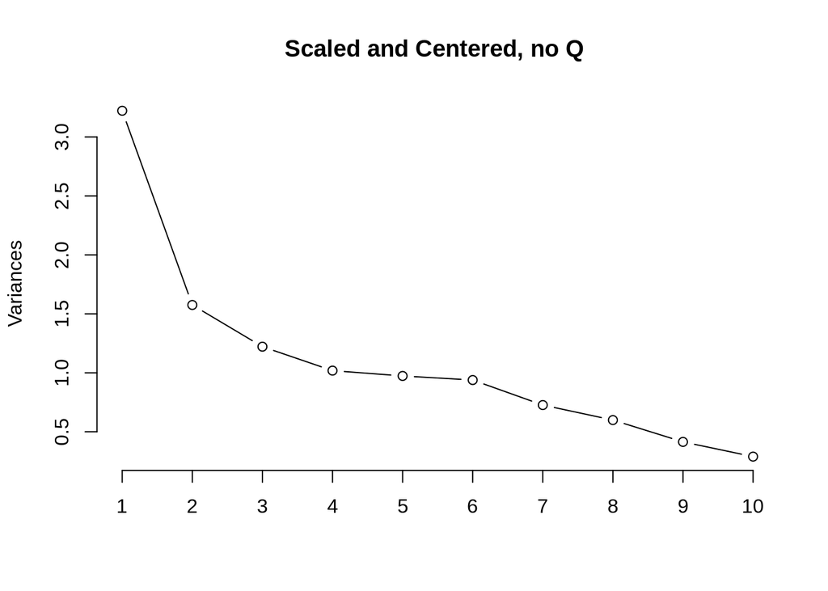

```r
plot(wine_pca_for_Q, type = "l", main = "Scaled and Centered, no Q " )
```

From the scree plot, we can see that the inflection point happens at component #6. Typical convention tells us that we can now discard from component #7 and on. We will see how the models performed when we subset the data with only the first six features.

```r
#####################################################

#Turn quality field into factor
wine$quality <- as.factor(wine$quality)
```

```r
##################################################################################
                            #    #     #     #    #     #
# knn starts below          #  #       # #   #    # #   #
                            # #        #  #  #    #  #  #
                            #  #       #   # #    #   # #
                            #    #     #     #    #     #
###################################################################################
```

```r
##Generate a random number that is 90% of the total number of rows in dataset.
 #ran <- sample(1:nrow(iris), 0.9 * nrow(iris))

set.seed(22)
wine_ran <- sample(1:nrow(wine), 0.9 * nrow(wine))

 ##the normalization function is created
 nor <-function(x) { (x -min(x))/(max(x)-min(x))   }
```

```r
##Run normalization on first 11 columns of data set because they are the predictors

# Normalization ensures that all features are mapped to the same range of values. The values are "normalized to be from 0.0 to 1.0".  Standardization means that the range of value are "standardized" to measure how many staandard deviations the value is from its mean.

wine_knn_norm <- as.data.frame(lapply(wine[,c(1,2,3,4,5,6,7,8,9,10,11)], nor))

summary(wine_knn_norm)
```

```
##  fixed.acidity    volatile.acidity  citric.acid     residual.sugar
##  Min.   :0.0000   Min.   :0.0000   Min.   :0.0000   Min.   :0.00000
##  1st Qu.:0.2404   1st Qu.:0.1275   1st Qu.:0.1627   1st Qu.:0.01687
##  Median :0.2885   Median :0.1765   Median :0.1928   Median :0.07055
##  Mean   :0.2937   Mean   :0.1944   Mean   :0.2013   Mean   :0.08883
##  3rd Qu.:0.3365   3rd Qu.:0.2353   3rd Qu.:0.2349   3rd Qu.:0.14264
##  Max.   :1.0000   Max.   :1.0000   Max.   :1.0000   Max.   :1.00000
##    chlorides       free.sulfur.dioxide total.sulfur.dioxide    density
##  Min.   :0.00000   Min.   :0.00000     Min.   :0.0000       Min.   :0.00000
##  1st Qu.:0.08012   1st Qu.:0.07317     1st Qu.:0.2297       1st Qu.:0.08892
##  Median :0.10089   Median :0.11150     Median :0.2900       Median :0.12782
##  Mean   :0.10912   Mean   :0.11606     Mean   :0.3001       Mean   :0.13336
##  3rd Qu.:0.12166   3rd Qu.:0.15331     3rd Qu.:0.3666       3rd Qu.:0.17332
##  Max.   :1.00000   Max.   :1.00000     Max.   :1.0000       Max.   :1.00000
##        pH           sulphates         alcohol
##  Min.   :0.0000   Min.   :0.0000   Min.   :0.0000
##  1st Qu.:0.3364   1st Qu.:0.2209   1st Qu.:0.2419
##  Median :0.4182   Median :0.2907   Median :0.3871
##  Mean   :0.4257   Mean   :0.3138   Mean   :0.4055
##  3rd Qu.:0.5091   3rd Qu.:0.3837   3rd Qu.:0.5484
##  Max.   :1.0000   Max.   :1.0000   Max.   :1.0000
```

```r
##extract training set
#iris_train <- iris_norm[ran,]

# use system.time to get the length of time it takes to run a function
wine_knn_train <- wine_knn_norm[wine_ran,]
wine_rf_train <- wine[wine_ran,]
```

```r
head(wine_knn_train)
```

```
##      fixed.acidity volatile.acidity citric.acid residual.sugar  chlorides
## 3558     0.4134615       0.11764706   0.1686747    0.004601227 0.04154303
## 1354     0.2788462       0.09803922   0.1807229    0.088957055 0.11572700
## 2769     0.3750000       0.21568627   0.2048193    0.009202454 0.11572700
## 3956     0.3076923       0.07843137   0.1807229    0.030674847 0.10089021
## 3002     0.2692308       0.11764706   0.1626506    0.157975460 0.08605341
## 3272     0.2596154       0.23529412   0.2048193    0.078220859 0.10385757
##      free.sulfur.dioxide total.sulfur.dioxide    density        pH sulphates
## 3558         0.163763066            0.1809745 0.06766917 0.1818182 0.1627907
## 1354         0.132404181            0.5614849 0.16367843 0.5181818 0.3488372
## 2769         0.006968641            0.2552204 0.07191055 0.4181818 0.1395349
## 3956         0.111498258            0.1879350 0.06477733 0.1454545 0.2906977
## 3002         0.094076655            0.2807425 0.15133989 0.3545455 0.2558140
## 3272         0.087108014            0.1902552 0.09118951 0.5090909 0.4418605
##        alcohol
## 3558 0.5000000
## 1354 0.3225806
## 2769 0.6612903
## 3956 0.5161290
## 3002 0.4032258
## 3272 0.6451613
```

```r
##extract testing set

wine_knn_test <- wine_knn_norm[-wine_ran,]
wine_rf_test <- wine[-wine_ran,]
```

```r
##extract 12th column of train dataset because it will be used as 'cl' argument in knn function.
wine_knn_target_category <- wine[wine_ran, 12]
wine_rf_target_category <- wine[wine_ran, 12]
head(wine_knn_target_category)
```

```
## [1] 6 5 6 6 7 7
## Levels: 3 4 5 6 7 8 9
```

```r
str(wine_knn_target_category)
```

```
##  Factor w/ 7 levels "3","4","5","6",..: 4 3 4 4 5 5 3 4 4 4 ...
```

```r
##extract 12th column of "test" dataset to measure the accuracy
wine_knn_test_category <- wine[-wine_ran, 12]
wine_rf_test_category <- wine[-wine_ran, 12]
```

```r
##load the package class
 library(class)
```

```r
str(wine_knn_train)
```

```
## 'data.frame':    4408 obs. of  11 variables:
##  $ fixed.acidity       : num  0.413 0.279 0.375 0.308 0.269 ...
##  $ volatile.acidity    : num  0.1176 0.098 0.2157 0.0784 0.1176 ...
##  $ citric.acid         : num  0.169 0.181 0.205 0.181 0.163 ...
##  $ residual.sugar      : num  0.0046 0.089 0.0092 0.0307 0.158 ...
##  $ chlorides           : num  0.0415 0.1157 0.1157 0.1009 0.0861 ...
##  $ free.sulfur.dioxide : num  0.16376 0.1324 0.00697 0.1115 0.09408 ...
##  $ total.sulfur.dioxide: num  0.181 0.561 0.255 0.188 0.281 ...
##  $ density             : num  0.0677 0.1637 0.0719 0.0648 0.1513 ...
##  $ pH                  : num  0.182 0.518 0.418 0.145 0.355 ...
##  $ sulphates           : num  0.163 0.349 0.14 0.291 0.256 ...
##  $ alcohol             : num  0.5 0.323 0.661 0.516 0.403 ...
```

```r
str(wine_knn_test)
```

```
## 'data.frame':    490 obs. of  11 variables:
##  $ fixed.acidity       : num  0.308 0.413 0.365 0.192 0.279 ...
##  $ volatile.acidity    : num  0.186 0.137 0.578 0.186 0.157 ...
##  $ citric.acid         : num  0.2169 0.259 0.0843 0.1205 0.2349 ...
##  $ residual.sugar      : num  0.3083 0.0138 0.0138 0.2201 0.0353 ...
##  $ chlorides           : num  0.107 0.104 0.193 0.104 0.487 ...
##  $ free.sulfur.dioxide : num  0.1498 0.0906 0.0801 0.0697 0.2125 ...
##  $ total.sulfur.dioxide: num  0.374 0.278 0.369 0.394 0.343 ...
##  $ density             : num  0.268 0.129 0.127 0.175 0.127 ...
##  $ pH                  : num  0.255 0.455 0.3 0.591 0.345 ...
##  $ sulphates           : num  0.267 0.267 0.337 0.174 0.14 ...
##  $ alcohol             : num  0.129 0.484 0.21 0.355 0.226 ...
```

```r
str(wine_knn_target_category)
```

```
##  Factor w/ 7 levels "3","4","5","6",..: 4 3 4 4 5 5 3 4 4 4 ...
```

```r
#system.time added to measure model's running time

knn_time <- system.time(wine_knn_model <- knn(wine_knn_train, wine_knn_test, cl=wine_knn_target_category, k=13 ))

knn_time
```

```
##    user  system elapsed
##   0.031   0.000   0.032
```

```r
knn_time_5 <- system.time(wine_knn_model_5 <- knn(wine_knn_train, wine_knn_test, cl=wine_knn_target_category, k=5 ))

knn_time_5
```

```
##    user  system elapsed
##   0.028   0.000   0.028
```

```r
#install.packages('e1071', dependencies = TRUE)
library(caret)
##create confusion matrix
 #tab <- table(pr,iris_test_category)

wine_knn_Conf_Matrix <- table(wine_knn_model,wine_knn_test_category)
wine_knn_Conf_Matrix_5<- table(wine_knn_model_5,wine_knn_test_category)
```

```r
confusionMatrix(wine_knn_Conf_Matrix)
```

```
## Confusion Matrix and Statistics
##
##               wine_knn_test_category
## wine_knn_model   3   4   5   6   7   8   9
##              3   0   0   0   0   0   0   0
##              4   0   1   1   1   0   0   0
##              5   0   9  96  41   2   0   0
##              6   1   6  48 161  37   7   0
##              7   0   0   5  25  35   6   0
##              8   0   0   0   5   3   0   0
##              9   0   0   0   0   0   0   0
##
## Overall Statistics
##
##                Accuracy : 0.598
##                  95% CI : (0.553, 0.6417)
##     No Information Rate : 0.4755
##     P-Value [Acc > NIR] : 3.574e-08
##
##                   Kappa : 0.3637
##
##  Mcnemar's Test P-Value : NA
##
## Statistics by Class:
##
##                      Class: 3 Class: 4 Class: 5 Class: 6 Class: 7 Class: 8
## Sensitivity          0.000000 0.062500   0.6400   0.6910  0.45455  0.00000
## Specificity          1.000000 0.995781   0.8471   0.6148  0.91283  0.98323
## Pos Pred Value            NaN 0.333333   0.6486   0.6192  0.49296  0.00000
## Neg Pred Value       0.997959 0.969199   0.8421   0.6870  0.89976  0.97303
## Prevalence           0.002041 0.032653   0.3061   0.4755  0.15714  0.02653
## Detection Rate       0.000000 0.002041   0.1959   0.3286  0.07143  0.00000
## Detection Prevalence 0.000000 0.006122   0.3020   0.5306  0.14490  0.01633
## Balanced Accuracy    0.500000 0.529140   0.7435   0.6529  0.68369  0.49161
##                      Class: 9
## Sensitivity                NA
## Specificity                 1
## Pos Pred Value             NA
## Neg Pred Value             NA
## Prevalence                  0
## Detection Rate              0
## Detection Prevalence        0
## Balanced Accuracy          NA
```

```r
confusionMatrix(wine_knn_Conf_Matrix_5)
```

```
## Confusion Matrix and Statistics
##
##                 wine_knn_test_category
## wine_knn_model_5   3   4   5   6   7   8   9
##                3   0   0   0   0   0   0   0
##                4   0   1   4   1   0   0   0
##                5   0   9  87  37   5   1   0
##                6   1   5  53 160  28   5   0
##                7   0   1   5  32  42   6   0
##                8   0   0   1   3   2   1   0
##                9   0   0   0   0   0   0   0
##
## Overall Statistics
##
##                Accuracy : 0.5939
##                  95% CI : (0.5489, 0.6377)
##     No Information Rate : 0.4755
##     P-Value [Acc > NIR] : 9.684e-08
##
##                   Kappa : 0.3657
##
##  Mcnemar's Test P-Value : NA
##
## Statistics by Class:
##
##                      Class: 3 Class: 4 Class: 5 Class: 6 Class: 7 Class: 8
## Sensitivity          0.000000 0.062500   0.5800   0.6867  0.54545 0.076923
## Specificity          1.000000 0.989451   0.8471   0.6420  0.89346 0.987421
## Pos Pred Value            NaN 0.166667   0.6259   0.6349  0.48837 0.142857
## Neg Pred Value       0.997959 0.969008   0.8205   0.6933  0.91337 0.975155
## Prevalence           0.002041 0.032653   0.3061   0.4755  0.15714 0.026531
## Detection Rate       0.000000 0.002041   0.1776   0.3265  0.08571 0.002041
## Detection Prevalence 0.000000 0.012245   0.2837   0.5143  0.17551 0.014286
## Balanced Accuracy    0.500000 0.525976   0.7135   0.6644  0.71946 0.532172
##                      Class: 9
## Sensitivity                NA
## Specificity                 1
## Pos Pred Value             NA
## Neg Pred Value             NA
## Prevalence                  0
## Detection Rate              0
## Detection Prevalence        0
## Balanced Accuracy          NA
```